# Plotting Phylogenetic trees with ggtree

25 May, 2020

## Phylogenetic trees in R

### **Working In Base R**

1. APE - Analyses of Phylogenetics an Evolution
   - “Analysis of Phylogenetic and Evolution with R” by E Paradis
   - There is a book!
   - Version 5 - maintained & great email community (r-sig-phylo@r-project.org)
2. Phytools - Liam Revell
   - Phylogenetic comparative methods
   - Also plotting functions
   - excellent blog - http://blog.phytools.org

## Phylogenetic trees in R

### **Working In Base R**

```r
library(ape)
tree <- read.tree("example_data/test_tree.tre")
tree
```

```
##
## Phylogenetic tree with 7 tips and 6 internal nodes.
##
## Tip labels:
##  A, B, C, D, E, F, ...
##
## Rooted; no branch lengths.
```

## Phylogenetic trees in R

### **Working In Base R**

```r
tree$tip.label
```

```
## [1] "A" "B" "C" "D" "E" "F" "G"
```

```r
tree$edge
```

```
##       [,1] [,2]
##  [1,]    8    9
##  [2,]    9    1
##  [3,]    9    2
##  [4,]    8   10
##  [5,]   10    3
##  [6,]   10   11
##  [7,]   11   12
##  [8,]   12    4
##  [9,]   12    5
## [10,]   11   13
## [11,]   13    6
## [12,]   13    7
```

```r
tree$Nnode
```

```
## [1] 6
```

## Phylogenetic trees in R

### **Working In Base R**

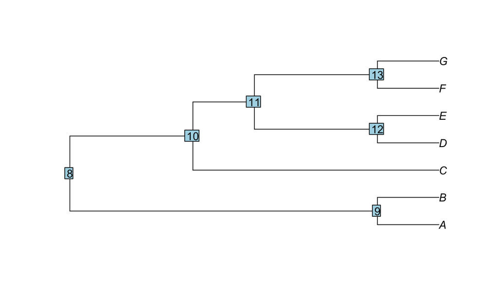

```r
plot(tree)
nodelabels()
```

## The ggtree Package

### **ggplot for Phylogenetic trees!**

G Yu. Using ggtree to visualize data on tree-like structures. Current Protocols in Bioinformatics, 2020, 69:e96. doi: 10.1002/cpbi.96.

### **Resources:**

Data Integration, Manipulation and Visualization of Phylogenetic Trees: https://yulab-smu.github.io/treedata-book/

[figure not shown]

## The ggtree Package

- Install via Bioconductor
- Dependancies: treeio, tidytree
- treeio: tree parser function
  - read.raxml, read.beast, read.iqtree etc…
- tidytree - your tree in the “tidyverse”
  - the treedata object

[output not shown]

[output not shown]

## The treedata object

```r
tree2 <- read.beast("example_data/Chaetodontidae.tre")
tree2
```

```
## 'treedata' S4 object that stored information of
##  'example_data/Chaetodontidae.tre'.
##
## ...@ phylo:
## Phylogenetic tree with 103 tips and 102 internal nodes.
##
## Tip labels:
##  Pomacanthus_rhomboides, Pomacanthus_annularis, Pomacanthus_sexstriatus, Pomacanthus_arcuatus, Pygoplites_diacanthus, Hemitaurichthys_thompsoni, ...
##
## Rooted; includes branch lengths.
##
## with the following features available:
##  'height',   'height_0.95_HPD',  'height_median',    'height_range', 'length',
##  'length_0.95_HPD',  'length_median',    'length_range', 'posterior',    'rate',
##  'rate_0.95_HPD',    'rate_median',  'rate_range'.
```

## The treedata object

```r
tree2@phylo
```

```
##
## Phylogenetic tree with 103 tips and 102 internal nodes.
##
## Tip labels:
##  Pomacanthus_rhomboides, Pomacanthus_annularis, Pomacanthus_sexstriatus, Pomacanthus_arcuatus, Pygoplites_diacanthus, Hemitaurichthys_thompsoni, ...
##
## Rooted; includes branch lengths.
```

## The treedata object

```r
tree2@data
```

```
## # A tibble: 205 x 14
##      height height_0.95_HPD height_median height_range length length_0.95_HPD
##       <dbl> <list>                  <dbl> <list>        <dbl> <list>
##  1 5.91e-12 <dbl [2]>            5.02e-12 <dbl [2]>     12.6  <dbl [2]>
##  2 5.91e-12 <dbl [2]>            5.02e-12 <dbl [2]>     12.6  <dbl [2]>
##  3 1.26e+ 1 <dbl [2]>            1.24e+ 1 <dbl [2]>     46.7  <dbl [2]>
##  4 5.91e-12 <dbl [2]>            5.21e-12 <dbl [2]>      9.77 <dbl [2]>
##  5 5.89e-12 <dbl [2]>            5.30e-12 <dbl [2]>      5.02 <dbl [2]>
##  6 5.91e-12 <dbl [2]>            5.30e-12 <dbl [2]>      5.56 <dbl [2]>
##  7 3.22e+ 0 <dbl [2]>            2.77e+ 0 <dbl [2]>      4.80 <dbl [2]>
##  8 5.90e-12 <dbl [2]>            5.22e-12 <dbl [2]>      7.60 <dbl [2]>
##  9 7.97e+ 0 <dbl [2]>            7.83e+ 0 <dbl [2]>      2.13 <dbl [2]>
## 10 1.03e+ 1 <dbl [2]>            1.01e+ 1 <dbl [2]>     14.7  <dbl [2]>
## # … with 195 more rows, and 8 more variables: length_median <dbl>,
## #   length_range <list>, posterior <dbl>, rate <dbl>, rate_0.95_HPD <list>,
## #   rate_median <dbl>, rate_range <list>, node <chr>
```

## The ggtree Package

### **Enter the “Phylo-verse”**

Essentially ggtree provides a **geom_tree** layer for ggplot

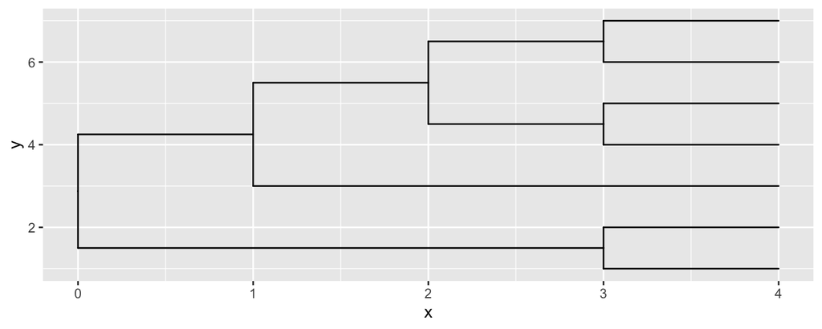

```r
ggplot() + geom_tree(data = tree)
```

## The ggtree Package

But ggtree provide a “wrapper” for this

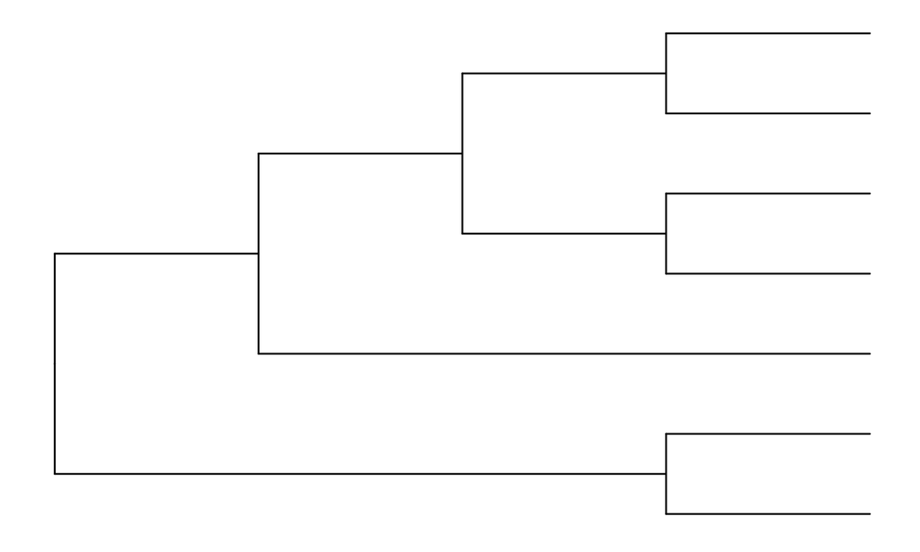

```r
ggtree(tree)
```

## Plotting with ggtree

- As with ggplot2, you work with **layers**
- The tree is a layer, the tip labels are a layer
- other annotation, or added data are layers linked to the tree by tips and nodes
- make aesthetic changes sam as ggplot2 and use of theme()

## Plotting with ggtree

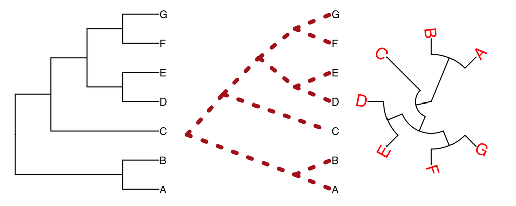

```r
p1 <- ggtree(tree) + geom_tiplab()
p2 <- ggtree(tree, layout = "slanted", color="firebrick", size=2, linetype="dotted") +
   geom_tiplab()
p3 <- ggtree(tree, layout = "fan") + geom_tiplab(size = 6, colour = "red")
multiplot(p1, p2, p3, ncol = 3)
```

## Plotting with ggtree

You can add various annotations

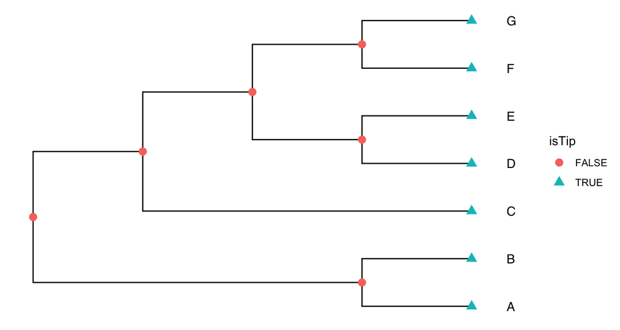

```r
ggtree(tree) +
   geom_tiplab(offset = 0.3) + geom_point(aes(shape=isTip, color=isTip), size=3)
```

## Plotting with ggtree {.smaller}

You can add various annotations

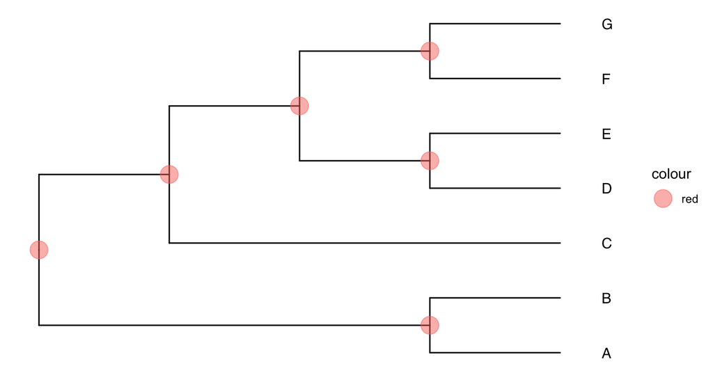

```r
ggtree(tree) +
   geom_tiplab(offset = 0.3) + geom_nodepoint(aes(color  = "red"), size=6, alpha = 0.5)
```

## Plotting with ggtree

Alter the theme

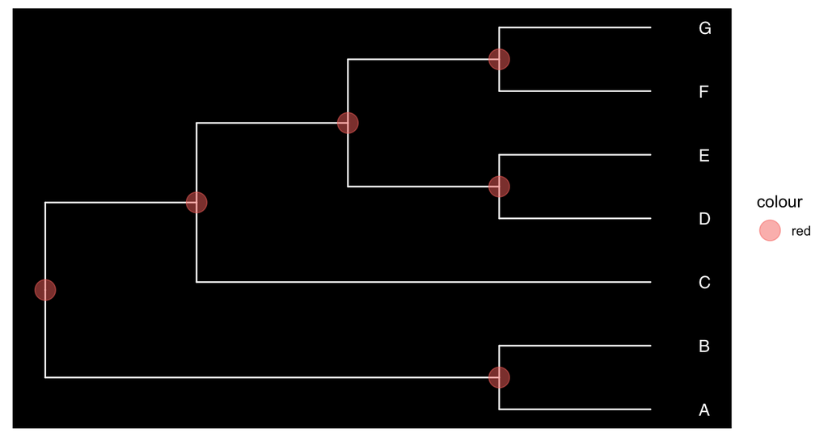

```r
p1 <- ggtree(tree, colour  = "white") + geom_tiplab(offset = 0.3, colour = "white") + geom_nodepoint(aes(color  = "red"), size=6, alpha = 0.5)

p1 + theme_tree(bgcolor = "black")
```

## Plotting with ggtree

Label a clade

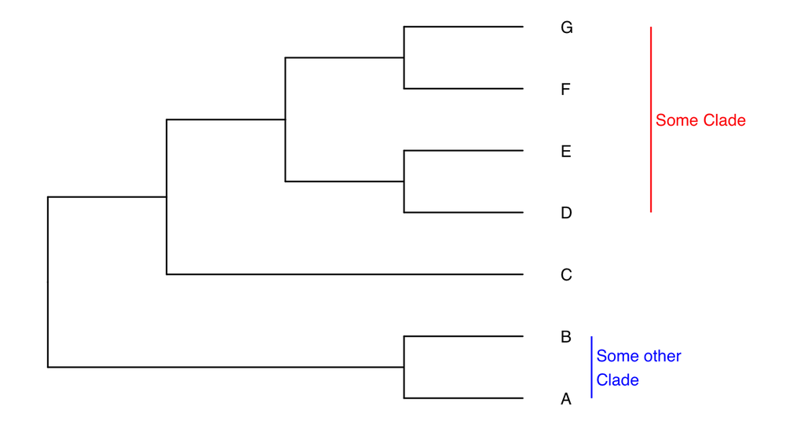

```r
ggtree(tree) +
   geom_tiplab(offset = 0.3) + xlim(NA, 6) +
   geom_cladelabel(node = 11, label  = "Some Clade", offset = 1, color='red') +
   geom_cladelabel(node = 9, label  = "Some other\nClade", offset = 0.5, color='blue')
```

## Plotting with ggtree

Grouping Taxa

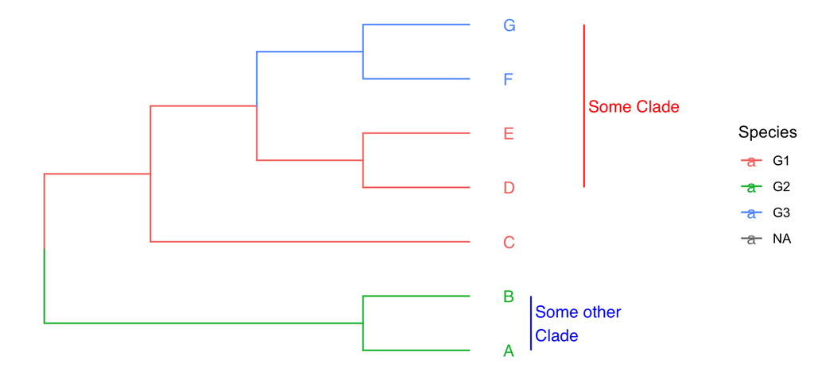

```r
grps <- list(G1 = c("C","D", "E"), G2 = c("A", "B"), G3 = c("F", "G"))
p <- ggtree(tree) + geom_tiplab(offset = 0.3) + xlim(NA, 6) + geom_cladelabel(node = 11, label  = "Some Clade", offset = 1, color='red') +
   geom_cladelabel(node = 9, label  = "Some other\nClade", offset = 0.5, color='blue')

groupOTU(p, grps, 'Species') + aes(color=Species) +
  theme(legend.position="right")
```

## Plotting with ggtree

Plotting a tree that has some data associated with the nodes

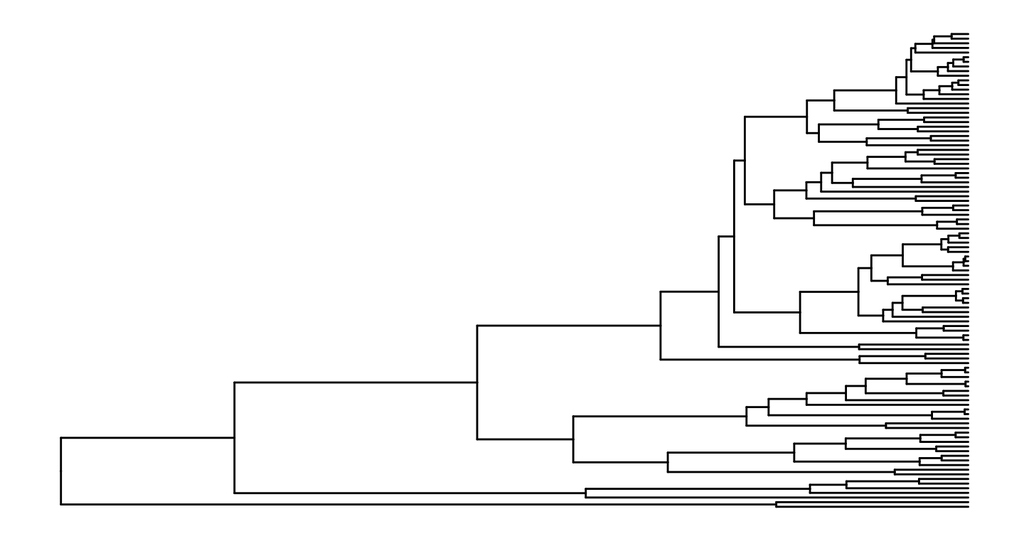

```r
ggtree(tree2)
```

## Plotting with ggtree

Plotting a tree that has some data associated with the nodes

```r
tree2@data %>% glimpse()
```

```
## Rows: 205
## Columns: 14
## $ height          <dbl> 5.910923e-12, 5.910923e-12, 1.255249e+01, 5.909963e-1…
## $ height_0.95_HPD <list> [<0.000000e+00, 1.420375e-11>, <0.000000e+00, 1.4203…
## $ height_median   <dbl> 5.016432e-12, 5.016432e-12, 1.239693e+01, 5.208278e-1…
## $ height_range    <list> [<0.000000e+00, 2.700773e-11>, <0.000000e+00, 2.7007…
## $ length          <dbl> 12.5524925, 12.5524925, 46.7373637, 9.7658842, 5.0225…
## $ length_0.95_HPD <list> [<8.471228, 16.864484>, <8.471228, 16.864484>, <38.8…
## $ length_median   <dbl> 12.3969322, 12.3969322, 46.3877728, 9.6555015, 5.1711…
## $ length_range    <list> [<6.006356, 25.907784>, <6.006356, 25.907784>, <30.9…
## $ posterior       <dbl> NA, NA, 1.00000, NA, NA, NA, 0.59252, NA, 0.72180, 0.…
## $ rate            <dbl> 0.002681417, 0.005180159, 0.004817979, 0.005304627, 0…
## $ rate_0.95_HPD   <list> [<0.0008610097, 0.0048317938>, <0.002527333, 0.00825…
## $ rate_median     <dbl> 0.002533378, 0.005019287, 0.004803852, 0.005004097, 0…
## $ rate_range      <list> [<0.0003951944, 0.0090818574>, <0.001366433, 0.01425…
## $ node            <chr> "102", "103", "105", "3", "1", "4", "110", "2", "109"…
```

## Plotting with ggtree

Plotting a tree that has some data associated with the nodes

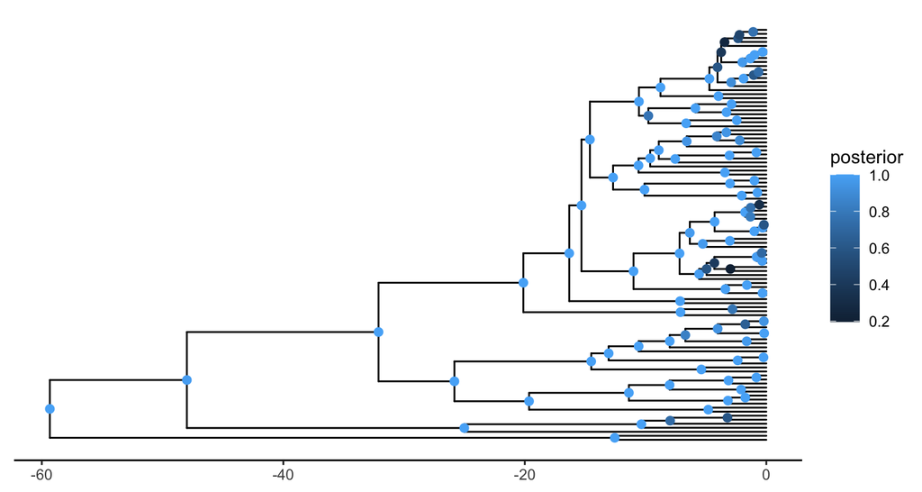

```r
p <- ggtree(tree2)
p1 <- revts(p)
p1 + geom_nodepoint(aes(colour = posterior), size = 2) + theme_tree2()
```

## Plotting with ggtree

Plotting a tree that has some data associated with the nodes

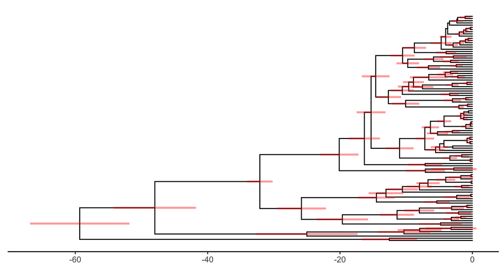

```r
p1 + geom_range(range='height_0.95_HPD', color='red', alpha=.4, size=1) + theme_tree2()
```

## Plotting with ggtree

### My goal

Completely plot a phylo figure in ggtree without then having to use illustrator to make adjustment

[figure not shown]

## Plotting with ggtree

Now i will move over to R to have some fun with tree plotting

**Cheers!**